# Stats 506 - Final project

Author

Hood Ahmed

Github link: https://github.com/hood-ahmed/final-project

# Packages

```r
library(tidyverse)
library(stargazer)
library(lme4)
library(sjPlot)
library(multcomp)
library(gridExtra)
library(patchwork)
library(broom)
library(psych)
```

# Reading the data

```r
# Just put them all in one file to do this. in stats course folder

setwd("C:/Users/hoods/OneDrive/Desktop/Stats 506/Final project/Data")

ab2 <- read.csv("AB2_English.csv")

ab3 <- read.csv("AB3_English.csv")

ab4 <- read.csv("ABIV_English.csv")
```

# Data Cleaning

When recoding, I was looking for variables that were there for the three waves so I can combine them. I had to eliminate several options since they were not available across all three waves.

## Recoding

```r
## Political Trust
# I reversed the order to make it more interpretable.
# so that 1 is no trust and 4 is high trust

ab2 <- ab2 %>%
  mutate_at(vars(q2011, q2012, q2013, q2014, q2015, q2016, q2017, q20112, q20114),
            list(~recode(., "4. i absolutely do not trust it" = 1,
                         "3. i trust it to a limited extent" = 2,
                         "2. i trust it to a medium extent" = 3,
                         "1. i trust it to a great extent" = 4)))


ab2 <- ab2 %>%
  mutate(country = recode(country,
                          "1. Algeria" = "Algeria",
                          "5. Egypt" = "Egypt",
                          "7. Iraq" = "Iraq",
                          "8. Jordan" = "Jordan",
                          "10. Lebanon" = "Lebanon",
                          "15. Palestine" = "Palestine",
                          "17. Saudi Arabia" = "Saudi Arabia",
                          "19. Sudan" = "Sudan",
                          "21. Tunisia" = "Tunisia",
                          "22. Yemen" = "Yemen"
                          ))

###### Performance evaluations

# Economy
ab2 <- ab2 %>%
  mutate_at(vars(q101),
            list(~recode(., "1. very good" = 1,
                         "2. good" = 2,
                         "3. bad" = 3,
                         "4. very bad" = 4)))
## Safety
ab2 <- ab2 %>%
  mutate_at(vars(q105),
            list(~recode(., "1. fully ensured" = 1,
                         "2. ensured" = 2,
                         "3. not ensured" = 3,
                         "4. absolutely not ensured" = 4)))

###### Sociocultural attitudes



ab2 <- ab2 %>%
  mutate_at(vars(q60102, q60103, q60104),
            list(~ recode(., "I strongly agree" = 1,
                          "I somewhat agree" = 2,
                          "I somewhat disagree" = 3,
                          "I strongly disagree" = 4)))
### Democracy


ab2 <- ab2 %>%
  mutate(q512 = recode(q512,
                       "1. absolutely unsatisfied" = 1,
                       "2"= 2,
                       "3" = 3,
                       "4" = 4,
                       "5" = 5,
                       "6" = 6,
                       "7" = 7,
                       "8" = 8,
                       "9" = 9,
                       "10. very satisfied" = 10))


### Religion:

# Public role
#
ab2 <- ab2 %>%
  mutate_at(vars(q6051, q6052, q6053, q6054, q6055, q6056),
            list(~ recode(., "1. i strongly agree" = 1,
                          "2. i agree" = 2,
                          "3. i disagree" = 3,
                          "4. i strongly disagree" = 4)))

ab2 <- ab2 %>%
  mutate_at(vars(q6061, q6062, q6063, q6064, q6065, q6066),
            list(~ recode(., "1. i strongly agree" = 1,
                          "2. i agree" = 2,
                          "3. i disagree" = 3,
                          "4. i strongly disagree" = 4)))

## Religiousity (self-reported)
ab2 <- ab2 %>%
  mutate(q609 = recode(q609,
                       "1. religious" = 1,
                       "2. somewhat religious" = 2,
                       "3. not religious" = 3))

## Religiousity (self-reported)
ab2 <- ab2 %>%
  mutate_at(vars(q6101, q6102, q6103, q6104, q6105, q6106, q6107),
            list(~ recode(., "1. always" = 1,
                          "2. most of the time" = 2,
                          "3. sometimes" = 3,
                          "4. rarely" = 4)))

############ Demographics

# Education

ab2 <- ab2 %>%
  mutate(q1003 = recode(q1003,
                       "1. Illiterate/literate" = 0,
                       "2. elementary" = 1,
                       "3. prepartory/basic" = 2,
                       "5. mid-level diploma/professional or technical" = 3,
                       "4. secondary" = 4,
                       "6, ba" = 5,
                       "7. ma and above" = 6
                       ))

# Religion

ab2 <- ab2 %>%
  mutate(q1012 = recode(q1012,
                       "1. muslim" = 1,
                       "2. christian" = 2))

## DV: Pol trust
ab3 <- ab3 %>%
  mutate_at(vars(q2011, q2013, q2014, q2016, q2017, q20112, q20113, q20114),
            list(~recode(., "I absolutely do not trust it" = 1,
                         "I trust it to a limited extent" = 2,
                         "I trust it to a medium extent" = 3,
                         "I trust it to a great extent" = 4)))

######## Performance

## Economy
ab3 <- ab3 %>%
  mutate_at(vars(q101),
            list(~recode(., "Very good" = 1,
                         "Good" = 2,
                         "Bad" = 3,
                         "Very bad" = 4)))

## Safety
ab3 <- ab3 %>%
  mutate_at(vars(q105),
            list(~recode(., "Fully ensured" = 1,
                         "Ensured" = 2,
                         "Not ensured" = 3,
                         "Absolutely not ensured" = 4)))

######## Socilcultural views

ab3 <- ab3 %>%
  mutate(q103 = recode(q103,
                            "Most people are trustworthy" = 1,
                            "Most people are not trustworthy" = 2))

############ Religion

ab3 <- ab3 %>%
  mutate_at(vars(q6051, q6052, q6053, q6054, q6055, q6056),
            list(~ recode(., "I strongly agree" = 1,
                          "I somewhat agree" = 2,
                          "I somewhat disagree" = 3,
                          "I strongly disagree" = 4)))

ab3 <- ab3 %>%
  mutate_at(vars(q6061, q6062, q6063, q6064, q6065, q6066),
            list(~ recode(., "I strongly agree" = 1,
                          "I somewhat agree" = 2,
                          "I somewhat disagree" = 3,
                          "I strongly disagree" = 4)))

##  Support for gender equality

ab3 <- ab3 %>%
  mutate_at(vars(q6012, q6013, q6014),
            list(~ recode(., "I strongly agree" = 1,
                          "I somewhat agree" = 2,
                          "I somewhat disagree" = 3,
                          "I strongly disagree" = 4)))

## Support for Democracy

ab3 <- ab3 %>%
  mutate(q512 = recode(q512,
                       "Absolutely inappropriate" = 1,
                       "2"= 2,
                       "3" = 3,
                       "4" = 4,
                       "5" = 5,
                       "6" = 6,
                       "7" = 7,
                       "8" = 8,
                       "9" = 9,
                       "Completely appropriate" = 10))

## Religiousity

ab3 <- ab3 %>%
  mutate(q609 = recode(q609,
                       "Religious" = 1,
                       "Somewhat religious" = 2,
                       "Not religious" = 3))

###### Demographics

# Sex

ab3 <- ab3 %>%
  mutate(sex = recode(sex,
                       "Male" = 0,
                       "Female" = 1))

# Religion

ab3 <- ab3 %>%
  mutate(q1012 = recode(q1012,
                       "Muslim" = 1,
                       "Christian" = 2))
# education

ab3 <- ab3 %>%
  mutate(q1003 = recode(q1003,
                       "Illiterate/No formal education" = 0,
                       "Elementary" = 1,
                       "Prepartory/Basic" = 2,
                       "Mid-level diploma (professional or technical)" = 3,
                       "Secondary" = 4,
                       "ba" = 5,
                       "MA and above" = 6
                       ))

## Pol Trust
ab4 <- ab4 %>%
  mutate_at(vars(q2011, q2013, q2014, q2016, q20113),
            list(~recode(., "No trust at all" = 1,
                         "Not very much trust" = 2,
                         "Quite a lot of trust" = 3,
                         "A great deal of trust" = 4)))

## Economy
ab4 <- ab4 %>%
  mutate_at(vars(q101),
            list(~recode(., "Very good" = 1,
                         "Good" = 2,
                         "Bad" = 3,
                         "Very bad" = 4)))

## Safety
ab4 <- ab4 %>%
  mutate_at(vars(q105),
            list(~recode(., "Fully ensured" = 1,
                         "Ensured" = 2,
                         "Not ensured" = 3,
                         "Absolutely not ensured" = 4)))

############## Sociocultural values

ab4 <- ab4 %>%
  mutate(q103 = recode(q103,
                            "Most people are trustworthy" = 1,
                            "Most people are not trustworthy" = 2))
####### Religion

# No q6065, q6066
ab4 <- ab4 %>%
  mutate_at(vars(q6061, q6062, q6063, q6064),
            list(~ recode(., "I strongly agree" = 1,
                          "I agree" = 2,
                          "I disagree" = 3,
                          "I strongly disagree" = 4)))

# Religiousity

ab4 <- ab4 %>%
  mutate(q609 = recode(q609,
                       "Religious" = 1,
                       "Somewhat religious" = 2,
                       "Not religious" = 3))


## support for gender equality

ab4 <- ab4 %>%
  mutate_at(vars(q6012, q6013, q6014),
            list(~ recode(., "I strongly agree" = 1,
                          "I agree" = 2,
                          "I disagree" = 3,
                          "I strongly disagree" = 4)))

## support for Democracy

ab4 <- ab4 %>%
  mutate(q512 = recode(q512,
                       "Completely inappropriate" = 1,
                       "2"= 2,
                       "3" = 3,
                       "4" = 4,
                       "5" = 5,
                       "6" = 6,
                       "7" = 7,
                       "8" = 8,
                       "9" = 9,
                       "Completely appropriate" = 10))

## X

###### Demographics

# Sex

ab4 <- ab4 %>%
  mutate(q1002 = recode(q1002,
                       "Male" = 0,
                       "Female" = 1))

# religion

ab4 <- ab4 %>%
  mutate(q1012 = recode(q1012,
                       "Muslim" = 1,
                       "Christian" = 2))
# education

ab4 <- ab4 %>%
  mutate(q1003 = recode(q1003,
                       "Illiterate/No formal education" = 0,
                       "Elementary" = 1,
                       "Prepartory/Basic" = 2,
                       "Mid-level diploma (professional or technical)" = 3,
                       "Secondary" = 4,
                       "ba" = 5,
                       "MA and above" = 6
                       ))
```

## Renaming

```r
# Pol trust
names(ab2)[names(ab2) == "q2011"]   <- "govt_trust" # DV
names(ab2)[names(ab2) == "q2012"]   <- "judiciary_trust"
names(ab2)[names(ab2) == "q2014"]   <- "police_trust"
names(ab2)[names(ab2) == "q2015"]   <- "parties_trust"
names(ab2)[names(ab2) == "q2016"]   <- "army_trust" # DV
names(ab2)[names(ab2) == "q20112"]  <- "islamist_trust_eg"
names(ab2)[names(ab2) == "q20114"]  <- "islamist_trust_tu"

### Performance

names(ab2)[names(ab2) == "q101"] <- "econ_performance"
names(ab2)[names(ab2) == "q105"] <- "safety"

### sociocultural views

names(ab2)[names(ab2) == "q609"] <- "religiousity"

names(ab2)[names(ab2) == "q512"] <- "support_for_democracy"

names(ab2)[names(ab2) == "q6062"] <- "support_for_secularism"

names(ab2)[names(ab2) == "q6012"] <- "support_for_gender_equality"

### Demographics

names(ab2)[names(ab2) == "q1012"] <- "religion"

names(ab2)[names(ab2) == "q1003"] <- "education"

# Pol trust
names(ab3)[names(ab3) == "q2011"]   <- "govt_trust"
names(ab3)[names(ab3) == "q2014"]   <- "police_trust"
names(ab3)[names(ab3) == "q2016"]   <- "army_trust"
names(ab3)[names(ab3) == "q20112"]  <- "islamist_trust"
names(ab3)[names(ab3) == "q20114"]  <- "islamist_trust_tu"

### Performance

names(ab3)[names(ab3) == "q101"] <- "econ_performance"
names(ab3)[names(ab3) == "q105"] <- "safety"


### sociocultural views


names(ab3)[names(ab3) == "q512"] <- "support_for_democracy"

names(ab3)[names(ab3) == "q6012"] <- "support_for_gender_equality"

# Religion
names(ab3)[names(ab3) == "q6052"] <- "support_for_sharia"

names(ab3)[names(ab3) == "q6062"] <- "support_for_secularism"

names(ab3)[names(ab3) == "q609"] <- "religiousity"

### Demographics

names(ab3)[names(ab3) == "q1012"] <- "religion"

names(ab3)[names(ab3) == "q1003"] <- "education"

### Political trust

names(ab4)[names(ab4) == "q2011"]   <- "govt_trust"
names(ab4)[names(ab4) == "q2014"]   <- "police_trust"
names(ab4)[names(ab4) == "q2016"]   <- "army_trust"
names(ab4)[names(ab4) == "q20112"]  <- "islamist_trust"

### Performance evaluation

names(ab4)[names(ab4) == "q101"] <- "econ_performance"
names(ab4)[names(ab4) == "q105"] <- "safety"

### Sociocultural views

# Religion
names(ab4)[names(ab4) == "q512"] <- "support_for_democracy"

names(ab4)[names(ab4) == "q6062"] <- "support_for_secularism"

names(ab4)[names(ab4) == "q609"] <- "religiousity"

### Demographics

names(ab4)[names(ab4) == "q1003"] <- "education"

names(ab4)[names(ab4) == "q1002"] <- "sex"

names(ab4)[names(ab4) == "q1012"] <- "religion"
```

## Factor analysis

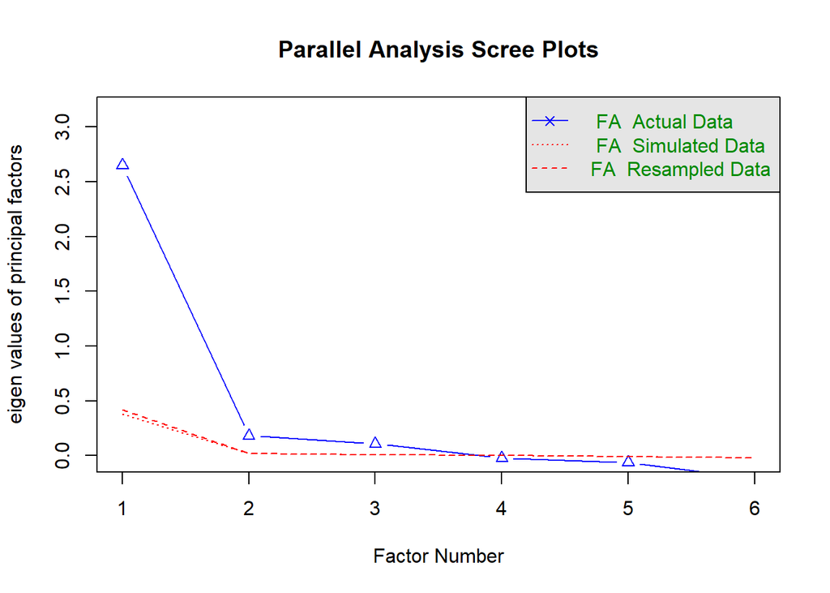

```
Parallel analysis suggests that the number of factors =  3  and the number of components =  NA
```

```r
data_fa <- ab2[, c('govt_trust', 'judiciary_trust', 'police_trust', 'parties_trust', 'army_trust', 'q2017')]

fa.parallel(data_fa, fa="fa", n.iter=100)
```

```r
fa_result <- fa(r = data_fa, nfactors = 2, rotate = "varimax")

loadings <- fa_result$loadings
```

# Merging the waves

I merge three waves into one data set. The three waves largely contain the same variables. I clean the data to make sure that the names and order of the variables match across all three waves and that the variables are on the same scale.

The resulting merged dataset shows how the values of the given country/society have been changing over time - rather than how the values of a selected group of people (panel) have been changing over their life. Therefore, methodologically, this dataset is a time-series but it is not a panel data-file (based on WVS technique).

```r
# create a year variable in each wave for when the survey was collected.
ab2$year <- 2011
ab3$year <- 2013
ab4$year <- 2016


ab2_subset <- ab2 %>%
  dplyr::select(qid, country, year,
         govt_trust, army_trust, econ_performance, safety, education,
         support_for_secularism, support_for_democracy, religion, religiousity)

ab3_subset <- ab3 %>%
  dplyr::select(qid, country, year,
         govt_trust, army_trust, econ_performance, safety, education,
         support_for_secularism, support_for_democracy, religion, religiousity)

ab4_subset <- ab4 %>%
  dplyr::select(qid, country, year,
         govt_trust, army_trust, econ_performance, safety, education,
         support_for_secularism, support_for_democracy, religion, religiousity)

time_series <- rbind(ab2_subset,ab3_subset, ab4_subset)
```

## **Create indices & country-level variables**

```r
time_series$performance_index <- (time_series$econ_performance + time_series$safety)/2

time_series$sociocultural_views <- (time_series$support_for_secularism + time_series$support_for_democracy)/2

### Regime types:

# Monarchy
time_series$monarchy = ifelse(time_series$country == "Algeria", 0,
              ifelse(time_series$country == "Egypt", 0,
              ifelse(time_series$country == "Iraq", 0,
              ifelse(time_series$country == "Jordan", 1,
              ifelse(time_series$country == "Saudi Arabia", 1,
              ifelse(time_series$country == "Lebanon", 0,
              ifelse(time_series$country == "Palestine", 0,
              ifelse(time_series$country == "Sudan", 0,
              ifelse(time_series$country == "Kuwait", 1,
              ifelse(time_series$country == "Yemen", 0,
              ifelse(time_series$country == "Libya", 0,
              ifelse(time_series$country == "Tunisia", 0,
              ifelse(time_series$country == "Morocco", 1, NA)))))))))))))

# polity score
time_series$polity2 = ifelse(time_series$country == "Algeria", 2,
              ifelse(time_series$country == "Egypt", -4,
              ifelse(time_series$country == "Iraq", 6,
              ifelse(time_series$country == "Jordan", -3,
              ifelse(time_series$country == "Saudi Arabia", -10,
              ifelse(time_series$country == "Lebanon", 6,
              ifelse(time_series$country == "Libya", 0,
              ifelse(time_series$country == "Sudan", -4,
              ifelse(time_series$country == "Yemen", 0,
              ifelse(time_series$country == "Kuwait", -7,
              ifelse(time_series$country == "Tunisia", 7,
              ifelse(time_series$country == "Morocco", -4, NA))))))))))))

time_series$regime_type <-ifelse(time_series$polity2 < 0, 0, 1)
```

## Country subsets

```r
alg <- subset(time_series, country == "Algeria")
eg <- subset(time_series, country == "Egypt")
ir <- subset(time_series, country == "Iraq")
jo <- subset(time_series, country == "Jordan")
lbn <- subset(time_series, country == "Lebanon")
pal <- subset(time_series, country == "Palestine")
sa <- subset(time_series, country == "Saudi Arabia")
su <- subset(time_series, country == "Sudan")
tu <- subset(time_series, country == "Tunisia")
yem <- subset(time_series, country == "Yemen")
```

# Descriptive statistics

I create means by country and by year for key variables.

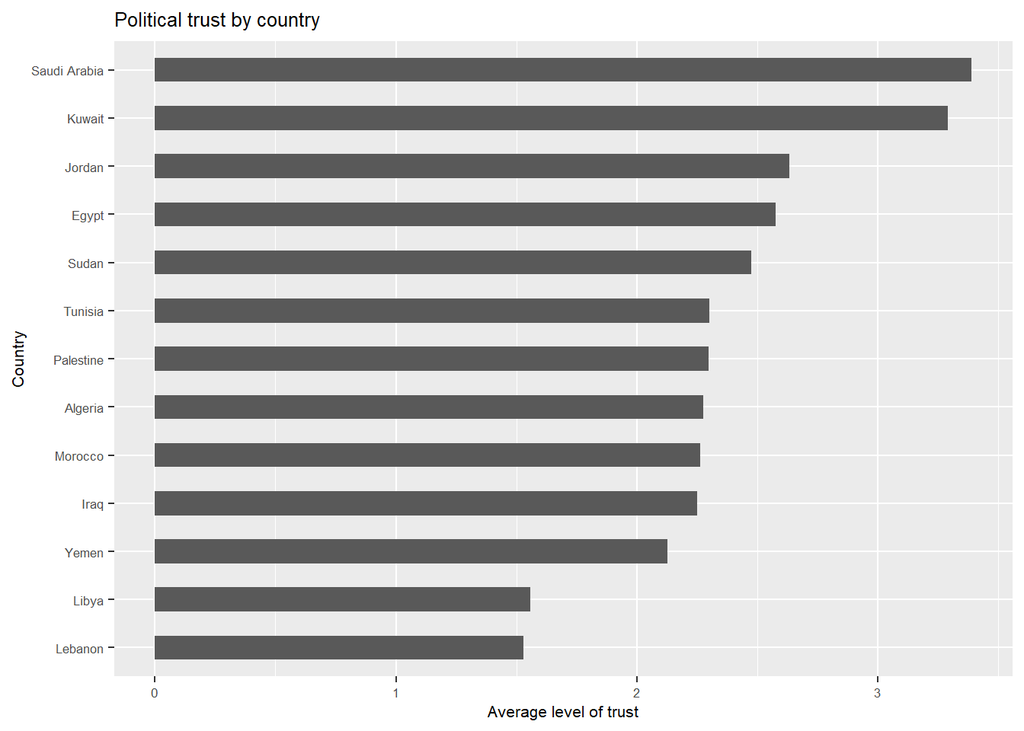

```r
time_series_by_country <- time_series %>%
  group_by(country) %>%
  summarise(
    govt_trust_avg = mean(govt_trust, na.rm = TRUE)
  )


ggplot(time_series_by_country, aes(reorder(country, govt_trust_avg), govt_trust_avg))+
  geom_col(width = 0.5)+
  coord_flip()+
  labs(title="Political trust by country") + xlab("Country") + ylab("Average level of trust")+
  theme(text = element_text(size = 8))
```

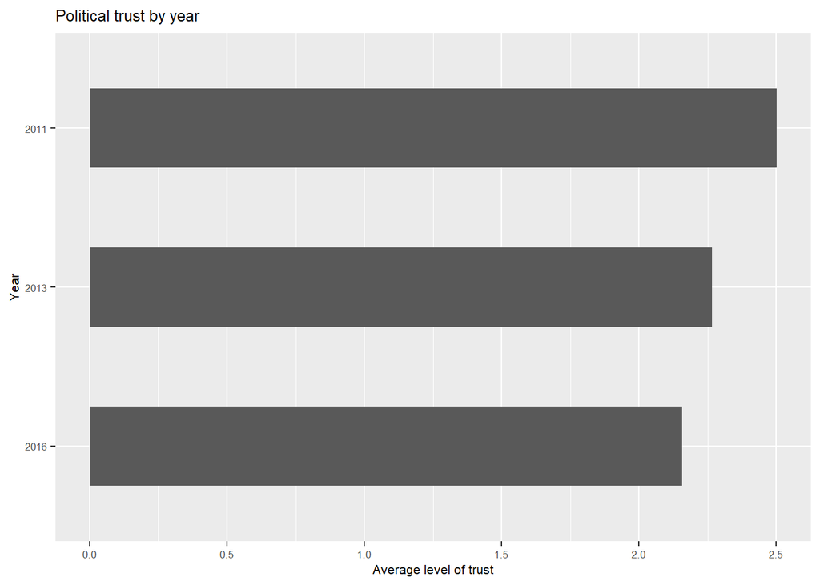

```r
# by year
time_series_by_year <- time_series %>%
  group_by(year) %>%
  summarise(
    performance_index_avg = mean(performance_index,na.rm = TRUE),
    govt_trust_avg = mean(govt_trust, na.rm = TRUE)
  )

ggplot(time_series_by_year, aes(reorder(year, govt_trust_avg), govt_trust_avg))+
  geom_col(width = 0.5)+
  coord_flip()+
  labs(title="Political trust by year") + xlab("Year") + ylab("Average level of trust")+
  theme(text = element_text(size = 8))
```

# Analysis

## Main Model

individuals’ level of trust likely depend on the country in which they live. Due to the fact that the model’s key independent variable is a characteristic of the country, multilevel models are the appropriate way to model this relationship. I use generalized linear mixed effect models that predict individuals’ levels of trust, allowing intercepts to vary between each country and year.

```r
# Country-fixed effects
m1 <- glmer(factor(govt_trust) ~ performance_index + sociocultural_views + monarchy + regime_type + (1|country) + education + religion, data = time_series, family = binomial)

# Year-fixed effects
m1_year <- glmer(factor(govt_trust) ~ performance_index + sociocultural_views + monarchy + regime_type + (1|year) + education + religion, data = time_series, family = binomial)

# Interaction between performance index and  country
m2 <- glmer(factor(govt_trust) ~ performance_index*(1|country) + sociocultural_views + monarchy + regime_type + education + religion, data = time_series, family = binomial)

table <- stargazer(m1, m1_year,
          dep.var.caption = "",
          column.labels = c("Political trust", "Year"),
          covariate.labels = c("Performance index", "Sociocultural Values",
                               "Government form", "Regime type", "Country", "Education", "Religion"),
          type="html", out="table.doc")
```

[output not shown]

## Predicted probability (pooled)

```r
modeldata.fig2 <- get_model_data(m1, type = "pred", terms = c("performance_index"))

plot.fig2 <- ggplot(modeldata.fig2, aes(colour = as.factor(group))) +
  geom_line(aes(x = x, y = predicted, group = group),
            lwd = 1/2, colour="black") +
  geom_ribbon(aes(x = x, ymin = conf.low, ymax = conf.high),
              alpha=0.1, colour = "black") +
  geom_point(aes(x = x, y = predicted, group = group),
             size=0.5, colour="black") +
  theme_bw() +
  theme(panel.grid.major = element_blank()) +
  theme(plot.title = element_text(hjust = 0.5)) +
  theme(legend.position = "bottom") +
  theme(legend.position="") + ggtitle("All Countries") +
  xlab("Performance Index") + ylab("Predicted level of trust")
```

## Predicted probability (by country)

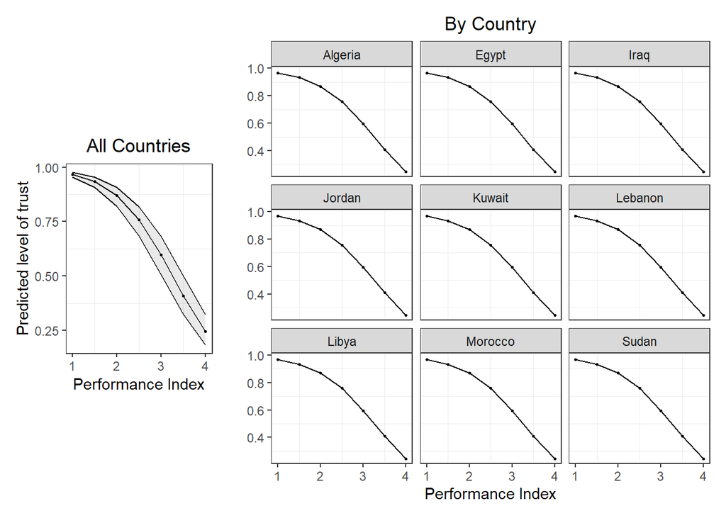

```r
modeldata.fig3 <- get_model_data(m2, type = "pred", terms = c("performance_index", "country"))

modeldata.fig3$group <- factor(modeldata.fig3$group, levels = c("Algeria"                         , "Egypt", "Iraq", "Jordan", "Kuwait", "Lebanon",                           "Libya", "Morocco", "Palestine", "Sudan",                                  "Tunisia", "Yemen"))


plot.fig3 <- ggplot(modeldata.fig3, aes()) + facet_wrap(vars(group), nrow=3) +
  geom_line(aes(x = x, y = predicted, group = group),
            lwd = 1/2, colour="black") +
  geom_ribbon(aes(x = x, ymin = conf.low, ymax = conf.high),
              alpha=0.1, colour="black") +
  geom_point(aes(x = x, y = predicted, group = group), size=0.5, colour="black") +
  theme_bw() +
  theme(panel.grid.major = element_blank()) +
  theme(plot.title = element_text(hjust = 0.5)) +
  theme(legend.position = "bottom") +
  ggtitle("By Country") + xlab("Performance Index") + ylab("")

layout5 <- "
#BBB
ABBB
ABBB
ABBB
#BBB
"

# Figure 1 - Combine both
combined_plots <- (plot.fig2) + plot.fig3 + plot_layout(design=layout5)

combined_plots
```

## Interaction plots: Regime Type

[figure not shown]

```r
# Figure 4: By democracy score
m4 <- glmer(factor(govt_trust) ~ performance_index*regime_type + sociocultural_views + monarchy + (1|country) + education + religion, data = time_series, family = binomial)

modeldata.fig4 <- get_model_data(m4, type = "pred", terms = c("performance_index", "regime_type"))

plot.fig4 <- ggplot(modeldata.fig4, aes(colour = as.factor(group),
                                          linetype = as.factor(group))) +
  geom_line(aes(x = x, y = predicted, group = group), lwd = 1/2) +
  geom_ribbon(aes(x = x, ymin = conf.low, ymax = conf.high), alpha=0.1) +
  geom_point(aes(x = x, y = predicted),size=2) +
  theme_bw() +
  theme(panel.grid.major = element_blank()) +
  theme(plot.title = element_text(hjust = 0.5)) +
  theme(legend.position = "bottom") +
  scale_colour_grey("Regime type: ", labels = c("Democracy", "Autocracy"), start = 0, end = 0.5, aesthetics = "colour") +
  xlab("Performance index") +ylab("Predicted Political Trust") +
  ggtitle("By democracy score")  + scale_linetype(guide = "none")


m5 <- glmer(factor(govt_trust) ~ performance_index*monarchy + regime_type + sociocultural_views + (1|country) + education + religion, data = time_series, family = binomial)

modeldata.fig5 <- get_model_data(m5, type = "pred", terms = c("performance_index", "monarchy"))

plot.fig5 <- ggplot(modeldata.fig5, aes(colour = as.factor(group),
                                          linetype = as.factor(group))) +
  geom_line(aes(x = x, y = predicted, group = group), lwd = 1/2) +
  geom_ribbon(aes(x = x, ymin = conf.low, ymax = conf.high), alpha=0.1) +
  geom_point(aes(x = x, y = predicted),size=2) +
  theme_bw() +
  theme(panel.grid.major = element_blank()) +
  theme(plot.title = element_text(hjust = 0.5)) +
  theme(legend.position = "bottom") +
  scale_colour_grey("", labels = c("Monarchy", "Republic"), start = 0, end = 0.5, aesthetics = "colour") +
  xlab("Performance index") +ylab("") +
  ggtitle("By form of government")  + scale_linetype(guide = "none")


plot.fig4 + plot.fig5
```

## By country

```r
alg_results <- glm(factor(govt_trust) ~ performance_index + sociocultural_views + monarchy + regime_type + education + religion, data = alg, family = binomial)

eg_results <- glm(factor(govt_trust) ~ performance_index + sociocultural_views + monarchy + regime_type + education + religion, data = eg, family = binomial)

ir_results <- glm(factor(govt_trust) ~ performance_index + sociocultural_views + monarchy + regime_type + education + religion, data = ir, family = binomial)

jo_results <- glm(factor(govt_trust) ~ performance_index + sociocultural_views + monarchy + regime_type + education + religion, data = jo, family = binomial)

lbn_results <- glm(factor(govt_trust) ~ performance_index + sociocultural_views + monarchy + regime_type + education + religion, data = lbn, family = binomial)

su_results <- glm(factor(govt_trust) ~ performance_index + sociocultural_views + monarchy + regime_type + education + religion, data = su, family = binomial)
# education
```

## Coefficient plots & hypothesis test

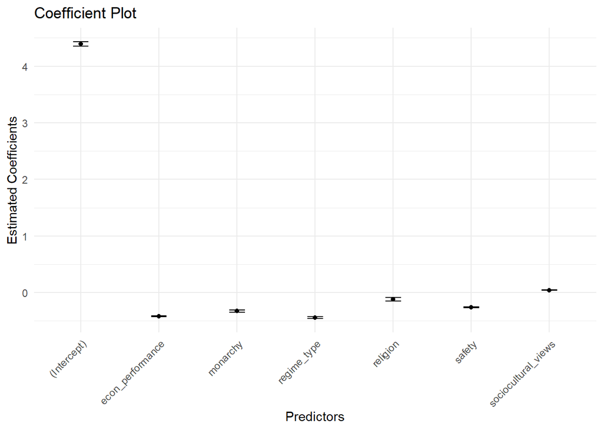

```r
# Linear model
m6 <- lm(govt_trust ~ econ_performance + safety + regime_type + sociocultural_views + monarchy +  religion, data = time_series)


tidied <- tidy(m6)

ggplot(tidied, aes(x = term, y = estimate)) +
  geom_point() +
  geom_errorbar(aes(ymin = estimate - std.error, ymax = estimate + std.error), width = 0.2) +
  theme_minimal() +
  labs(title = "Coefficient Plot",
       x = "Predictors",
       y = "Estimated Coefficients") +
  theme(axis.text.x = element_text(angle = 45, hjust = 1))
```

```r
summary(glht(m6, "econ_performance - safety = 0"))
```

```
     Simultaneous Tests for General Linear Hypotheses

Fit: lm(formula = govt_trust ~ econ_performance + safety + regime_type +
    sociocultural_views + monarchy + religion, data = time_series)

Linear Hypotheses:
                               Estimate Std. Error t value Pr(>|t|)
econ_performance - safety == 0 -0.16420    0.01214  -13.52   <2e-16 ***
---
Signif. codes:  0 '***' 0.001 '**' 0.01 '*' 0.05 '.' 0.1 ' ' 1
(Adjusted p values reported -- single-step method)
```